# Using K-means clustering to classify country happiness levels

### Using K-means clustering to classify country happiness levels.

- Written by Leonard Phillips

This Notebook will try to group country happiness levels using the unsupervised machine learning algorithm k-means clustering. This is my first attempt to learn and implement the k-means clustering algorithm. I will be using the sklearn library and a collection of indicators from the World Bank open database

```python
import pandas as pd
```

```python
WHRData = pd.read_csv('WHRData.csv')
WHRData.drop(columns=['Unnamed: 0'],inplace=True)
```

To begin, we will need to extract all OECD countries and place them into one dataframe for ease of workability

```python
oecd_names = ['Australia', 'Austria', 'Belgium', 'Canada', 'Chile', 'Czech Republic', 'Denmark', 'Estonia',
 'Finland', 'France', 'Germany', 'Greece', 'Hungary', 'Iceland', 'Ireland', 'Israel', 'Italy',
 'Japan', 'South Korea', 'Luxembourg', 'Mexico', 'Netherlands', 'New Zealand', 'Norway', 'Poland', 'Portugal',
 'Slovak Republic', 'Slovenia', 'Spain', 'Sweden', 'Switzerland', 'Turkey', 'United Kingdom', 'United States']

oecd_df = pd.DataFrame(columns=WHRData.columns)

for name in oecd_names:
    oecd_df = pd.concat([oecd_df,WHRData.loc[WHRData['Country name'] == name]],ignore_index=True)
```

#### Feature Scaling

Now that we have our workable OECD dataframe we will need to scale our prediction features in order to avoid a disproporational effect on the outcome which will lead to a degraded accuracy. The method of I have used is MinMaxScaling.

```python
from sklearn import preprocessing
for header in oecd_df.iloc[:, 3:].columns:
    minmax_scale = preprocessing.MinMaxScaler().fit(oecd_df[[header]].dropna())
    df_minmax_scale = minmax_scale.transform(oecd_df[[header]])
    oecd_df[[header]] = df_minmax_scale
```

```python
oecd_df['Life Ladder (between 0 and 10)'] = oecd_df['Life Ladder (between 0 and 10)'].round(2)
```

#### Removing NaN values

Our K means clustering model can not handle NaN values, therefore, we must remove them. However .dropna() will delete the entire row. If we clear the X_train dataset of NaN values, it goes from having 217 rows to 1 row. This is a major issue. One solution to this problem is replacing the NaN values with the mean of the column.

```python
def percent_of_nan(df):
    percents = {}
    for column in df.columns:
        num_of_nans = df[column].isna().sum()
        total_rows = df[column].count() + num_of_nans
        percent_nan = (num_of_nans / total_rows)*100
        percents[df[column].name] = round(percent_nan, 2)
    return percents
```

```python
from pprint import pprint

percentages = percent_of_nan(oecd_df)
dropped_columns = []
for key, value in percentages.items():
    if value > 40:
        dropped_columns.append(key)
        oecd_df.drop(key, axis=1, inplace=True)
print("Features deleted:")
pprint(dropped_columns)
```

```
Features deleted:
['GINI index (World Bank estimate)',
 'Most people can be trusted, Gallup',
 'Most people can be trusted, WVS round 1981-1984',
 'Most people can be trusted, WVS round 1989-1993',
 'Most people can be trusted, WVS round 1994-1998',
 'Most people can be trusted, WVS round 1999-2004',
 'Most people can be trusted, WVS round 2010-2014']
```

All NaN values must be replaced to satisfy our regression model. I will be using the mean of each column as a replacement.

```python
oecd_df.fillna(oecd_df.mean(), inplace=True)
```

#### Building the model

Now that the data has been cleaned and reshaped it is ready for analysis.

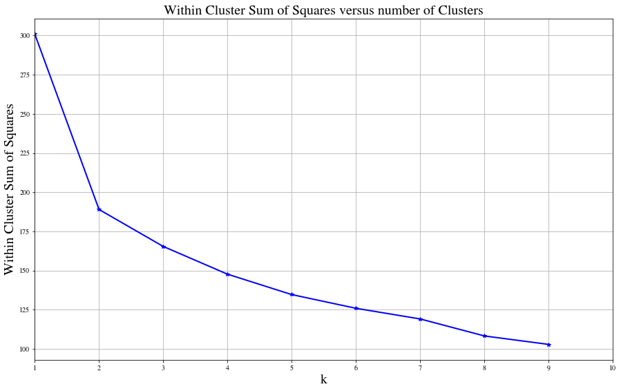

```python
from sklearn.cluster import KMeans
import matplotlib.pyplot as plt

from pylab import rcParams

rcParams['figure.figsize'] = 14, 8
rcParams['font.size'] = 20
rcParams['figure.dpi'] = 350
rcParams['lines.linewidth'] = 2
rcParams['axes.facecolor'] = 'white'
rcParams['patch.edgecolor'] = 'white'
rcParams['font.family'] = 'StixGeneral'
%matplotlib inline


k_rng = range(1,10)
est = [KMeans(n_clusters = k, init='random').fit(oecd_df.iloc[:,3:].values) for k in k_rng]

# Generally want to minimize WSS, while also minimizing k
within_cluster_sum_squares = [e.inertia_ for e in est]
fig, axes = plt.subplots()
fig.set_size_inches(15,20)

# Plot the results
plt.subplot(212)
plt.plot(k_rng, within_cluster_sum_squares, 'b*-')
plt.xlim([1,10])
plt.grid(True)
plt.xlabel('k', fontsize=20)
plt.ylabel('Within Cluster Sum of Squares', fontsize=20)
plt.title('Within Cluster Sum of Squares versus number of Clusters', fontsize=20)
```

After a visual examination of the plot above we can see that the clusters are becoming more cohesive as k increases. We can see the rate at which Sum of Squared is decreasing change when k=2. To find the best model we can start testing using k=2 until k=5 in our learning models.

Now that we know our range of k we want to calculate how well the clustering has performed. We can do this by producing a Silhouette Score for each model. The measure is between -1 (worst) and 1 (best). We also want to find a subset of features to use in our model. We can do this by looping over the clustering model, decreasing the number of features included with each iteration.

```python
for i in range(3, 24):
    print(25-i, " features included")
    for k in range(2, 6):
        km = KMeans(n_clusters=k, init='random')
        km.fit(oecd_df.iloc[:,i:].values)
        predictions = km.predict(oecd_df.iloc[:,i:].values)

        print("k =",k, ": ", metrics.silhouette_score(oecd_df.iloc[:,i:].values, predictions))
```

```
22  features included
k = 2 :  0.3185852398565567
k = 3 :  0.29334667838642
k = 4 :  0.19847727433257842
k = 5 :  0.24381449196074786
21  features included
k = 2 :  0.31212388523136153
k = 3 :  0.2659089939622955
k = 4 :  0.19830867868013535
k = 5 :  0.20341011687058824
20  features included
k = 2 :  0.3140409366308415
k = 3 :  0.25915628586458944
k = 4 :  0.19834084997221718
k = 5 :  0.23156633726297643
19  features included
k = 2 :  0.32449941420441003
k = 3 :  0.21763981264520904
k = 4 :  0.2371139158229092
k = 5 :  0.3143455730577583
18  features included
k = 2 :  0.3220824238818169
k = 3 :  0.2564369309103456
k = 4 :  0.3165923180069405
k = 5 :  0.22491347400772602
17  features included
k = 2 :  0.30890297044268544
k = 3 :  0.19466462430364453
k = 4 :  0.21998089539912305
k = 5 :  0.23168362091370376
16  features included
k = 2 :  0.27558398949494817
k = 3 :  0.26129515927057023
k = 4 :  0.2820819663762267
k = 5 :  0.19917966085183753
15  features included
k = 2 :  0.27191176327469024
k = 3 :  0.2516302602266062
k = 4 :  0.19562545694428982
k = 5 :  0.20172739074314897
```

[output cut: 50 more lines]

```
4  features included
k = 2 :  0.5028394821176471
k = 3 :  0.37783755174786327
k = 4 :  0.37856190319574756
k = 5 :  0.2950393524272961
3  features included
k = 2 :  0.6496693367038908
k = 3 :  0.4629437637535338
k = 4 :  0.471957080203397
k = 5 :  0.4825620669245698
2  features included
k = 2 :  0.8681943107074259
k = 3 :  0.676138593697914
k = 4 :  0.7571782390764489
k = 5 :  0.7758478930242751
```

Now that we know what parameters to use in the data we can start experimenting with feature subsets. I will be using the first four columns.

#### Final Model

The number of clusters I have selected for my final model is k=2. I will be using 'Log GDP per capita', 'Social support', 'Healthy life expectancy at birth' and 'Freedom to make life choices' as my features.

```python
feature_names = ['Log GDP per capita',
       'Social support', 'Healthy life expectancy at birth',
       'Freedom to make life choices']
```

```python
km = KMeans(n_clusters=2, init='random')
km.fit(oecd_df[feature_names].values)
predictions = km.predict(oecd_df[feature_names].values)
centers = km.cluster_centers_

print("k =",2, ": ", metrics.silhouette_score(oecd_df[feature_names].values, predictions))
```

```
k = 2 :  0.4818617914146042
```

To get a better sense of what each cluster looks I have graphically displayed the two clusters below.

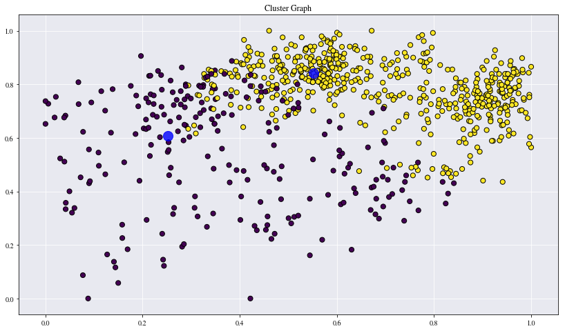

```python
fig, ax = plt.subplots(figsize=(14, 8))
ax.set_facecolor('#e8e9f0')
ax.grid(True, color='w')
ax.set_axisbelow(True)
ax.set_title('Cluster Graph')

plt.scatter(oecd_df['Log GDP per capita'].values, oecd_df['Social support'].values, c=predictions, s=50, edgecolors='black')
plt.scatter(oecd_df['Freedom to make life choices'].values, oecd_df['Healthy life expectancy at birth'].values, c=predictions, s=50, edgecolors='black')
plt.scatter(centers[:, 0], centers[:, 1], c='blue', s=200, alpha=0.8)
```

Now we will attempt to cluster each countries happiness by year with the model described above.

(Note: Uncomment the print statements to see the two clusters)

```python
clusters = []

for i in range(2):
    group = []
#     print('Group', i+1)
    for r, val in oecd_df.iterrows():
        if i == predictions[r]:
            if val[0] not in group:
                country = val[0] + ' ' + str(val[1]) + ' : ' + str(val[2])
                group.append(country)
#                 print(country)
    clusters.append(group)
#     print('\n')
```